# Bootstrap analysis of burial mound elevations

## Bootstrapping mound elevations in the Yambol Province

This script is inspired by Kyle Bocinsky’s comparison of cell tower elevations with background terrain in this *How to do archaeological science using R* [chapter](https://benmarwick.github.io/How-To-Do-Archaeological-Science-Using-R/landscape-based-hypothesis-testing-in-r.html). I have adapted the script to burial mounds elevation in the Yambol Province in SE Bulgaria and adjusted the wrangling of the simulated results to compensate for older libraries.

## Load mounds and elevation raster clipped by Yambol region boundary

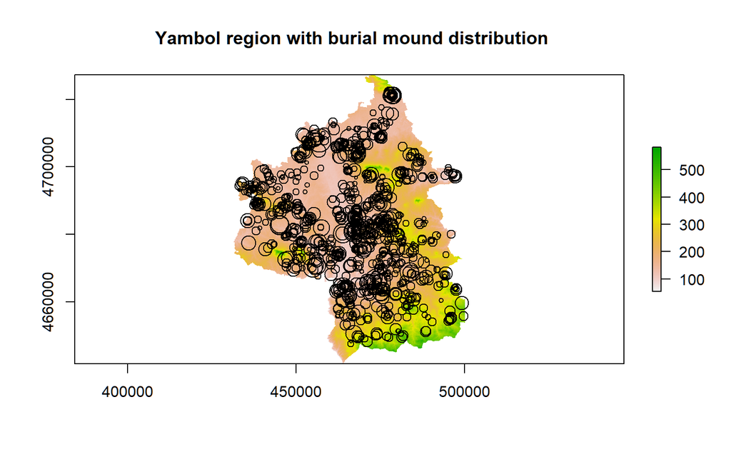

```r
Yam_mnds <- readRDS("../output_data/Yam_mnds.rds")
Y_elev <- raster("../output_data/large/Yelev32635.tif")
plot(Y_elev, main = " Yambol region with burial mound distribution")
plot(Yam_mnds$geometry, cex = sqrt(Yam_mnds$HeightMax), add = T)
```

## Random sample of regional elevations

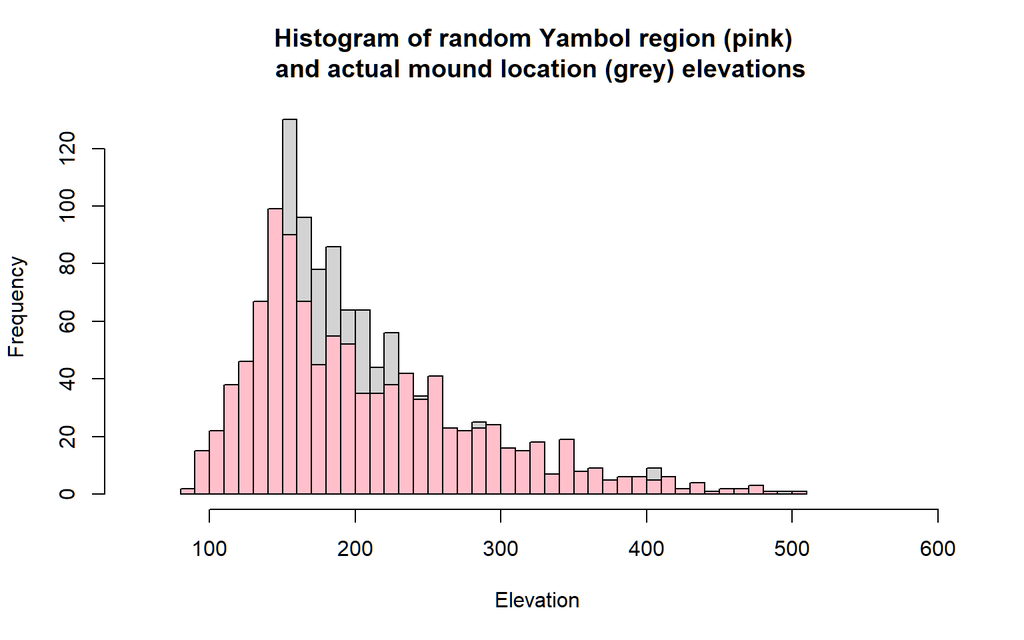

```r
random <- sampleRandom(Y_elev, 1050)  # generate sample as big as the mounds

hist(Yam_mnds$elevAster, breaks = 35, main = "Histogram of random Yambol region (pink) \n and actual mound location (grey) elevations",
    xlim = c(50, 600), xlab = "Elevation")
hist(random, col = "pink", breaks = 35, add = T, alpha = 0.8)
```

let’s look at the data with `ggplot`

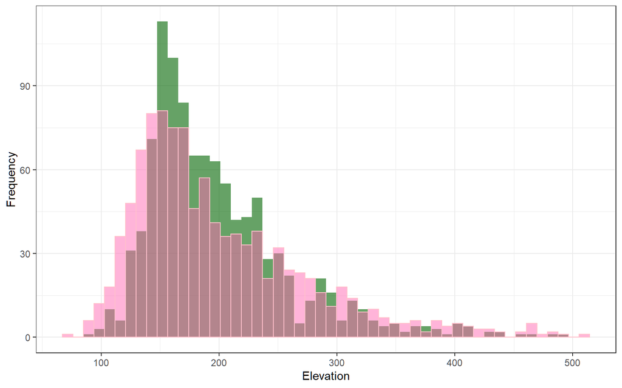

```r
Yam_mnds$random <- sampleRandom(Y_elev, 1050)  # ggplot wants a dataframe, not a vector

ggplot(data = Yam_mnds) + geom_histogram(aes(elevAster), bins = 50, fill = "darkgreen",
    alpha = 0.6) + geom_histogram(aes(random), bins = 50, alpha = 0.5, fill = "hotpink",
    colour = "pink") + labs(x = "Elevation", y = "Frequency") + theme_bw()
```

There seems to be a considerable overlap, but we only compared the mound elevations (green) to one sample of regional elevations (pink). So let’s try with a larger sample size.